# The Gottingen Videos

YouTube lectures by Christoph Scherber

Bruce Hartman

2026-10-22 Revised 2026-10-22T09:53:05

Abstract

We update the Gottingen Videos R code to the latest tidyverse methods.

# Introduction

These videos by Christoph Scherber outline the whys and wherefores of regression in simple language. Scherber is a professor at the University of Gottingen in Germany, one of the finest scientific institutions in the world.

In this notebook I display the code and results that go with the video, and use the updated tidyverse version when it is appropriate.

Enjoy the videos and follow along.

# Packages

We use the customary packages.

```r
library(mbadtools) # used to manipulate data and plot
lib_packages(mbad_standard_packages)
```

```
Loading MBAD packages:
 tidyverse ggfortify GGally skimr broom gt patchwork car yardstick ggResidpanel
```

# Gottingen 1

[The first video](https://youtu.be/Xh6Rex3ARjc)

## Data

Data is available from the `datasets` package, part of R.

```r
?airquality
glimpse(airquality)
```

```
Rows: 153
Columns: 6
$ Ozone   <int> 41, 36, 12, 18, NA, 28, 23, 19, 8, NA, 7, 16, 11, 14, 18, 14, …
$ Solar.R <int> 190, 118, 149, 313, NA, NA, 299, 99, 19, 194, NA, 256, 290, 27…
$ Wind    <dbl> 7.4, 8.0, 12.6, 11.5, 14.3, 14.9, 8.6, 13.8, 20.1, 8.6, 6.9, 9…
$ Temp    <int> 67, 72, 74, 62, 56, 66, 65, 59, 61, 69, 74, 69, 66, 68, 58, 64…
$ Month   <int> 5, 5, 5, 5, 5, 5, 5, 5, 5, 5, 5, 5, 5, 5, 5, 5, 5, 5, 5, 5, 5,…
$ Day     <int> 1, 2, 3, 4, 5, 6, 7, 8, 9, 10, 11, 12, 13, 14, 15, 16, 17, 18,…
```

```r
airquality # all the data in a pageable format
```

| Ozone | Solar.R | Wind | Temp | Month | Day |
| --- | --- | --- | --- | --- | --- |
| 41 | 190 | 7.4 | 67 | 5 | 1 |
| 36 | 118 | 8.0 | 72 | 5 | 2 |
| 12 | 149 | 12.6 | 74 | 5 | 3 |
| 18 | 313 | 11.5 | 62 | 5 | 4 |
| NA | NA | 14.3 | 56 | 5 | 5 |
| 28 | NA | 14.9 | 66 | 5 | 6 |
| 23 | 299 | 8.6 | 65 | 5 | 7 |
| 19 | 99 | 13.8 | 59 | 5 | 8 |
| 8 | 19 | 20.1 | 61 | 5 | 9 |
| NA | 194 | 8.6 | 69 | 5 | 10 |

[output cut: 143 more lines]

## Data Examination

```r
airquality %>% skim
```

```
── Data Summary ────────────────────────
                           Values
Name                       Piped data
Number of rows             153
Number of columns          6
_______________________
Column type frequency:
  numeric                  6
________________________
Group variables            None
```

|  | skim_variable | n_missing | complete_rate | mean | sd | p0 | p25 | p50 | p75 | p100 | hist |
| --- | --- | --- | --- | --- | --- | --- | --- | --- | --- | --- | --- |
| 1 | Ozone | 37 | 0.7581699 | 42.129310 | 32.987885 | 1.0 | 18.00 | 31.5 | 63.25 | 168.0 | ▇▃▂▁▁ |
| 2 | Solar.R | 7 | 0.9542484 | 185.931507 | 90.058422 | 7.0 | 115.75 | 205.0 | 258.75 | 334.0 | ▅▃▅▇▅ |
| 3 | Wind | 0 | 1.0000000 | 9.957516 | 3.523001 | 1.7 | 7.40 | 9.7 | 11.50 | 20.7 | ▂▇▇▃▁ |
| 4 | Temp | 0 | 1.0000000 | 77.882353 | 9.465270 | 56.0 | 72.00 | 79.0 | 85.00 | 97.0 | ▂▃▇▇▃ |
| 5 | Month | 0 | 1.0000000 | 6.993464 | 1.416522 | 5.0 | 6.00 | 7.0 | 8.00 | 9.0 | ▇▇▇▇▇ |
| 6 | Day | 0 | 1.0000000 | 15.803922 | 8.864520 | 1.0 | 8.00 | 16.0 | 23.00 | 31.0 | ▇▇▇▇▆ |

```r
which(is.na(airquality))
```

```
 [1]   5  10  25  26  27  32  33  34  35  36  37  39  42  43  45  46  52  53  54
[20]  55  56  57  58  59  60  61  65  72  75  83  84 102 103 107 115 119 150 158
[39] 159 164 180 249 250 251
```

Lots of rows have missing data. `Ozone` is missing in 37 rows and `Solar.R` is missing in 7 rows.

### Visualize Data

We plot `Ozone` as a function of `Solar.R` solar radiation.

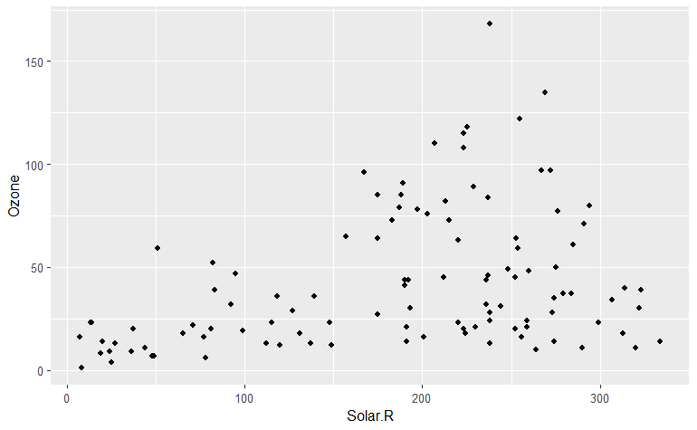

```r
ggplot(airquality) +
  geom_point(aes(Solar.R,Ozone))
```

The rows with missing values were not plotted. There is evidence of a linear trend, though not strong.

## Averages

Get averages from the `skim` output. But first we use the `mean` function to show the effect of missing values.

```r
mean(airquality$Ozone)
```

```
[1] NA
```

```r
airquality$Ozone
```

```
  [1]  41  36  12  18  NA  28  23  19   8  NA   7  16  11  14  18  14  34   6
 [19]  30  11   1  11   4  32  NA  NA  NA  23  45 115  37  NA  NA  NA  NA  NA
 [37]  NA  29  NA  71  39  NA  NA  23  NA  NA  21  37  20  12  13  NA  NA  NA
 [55]  NA  NA  NA  NA  NA  NA  NA 135  49  32  NA  64  40  77  97  97  85  NA
 [73]  10  27  NA   7  48  35  61  79  63  16  NA  NA  80 108  20  52  82  50
 [91]  64  59  39   9  16  78  35  66 122  89 110  NA  NA  44  28  65  NA  22
[109]  59  23  31  44  21   9  NA  45 168  73  NA  76 118  84  85  96  78  73
[127]  91  47  32  20  23  21  24  44  21  28   9  13  46  18  13  24  16  13
[145]  23  36   7  14  30  NA  14  18  20
```

```r
airquality %>% pull(Ozone) %>% mean
```

```
[1] NA
```

Because of the NAs in the Ozone column, the answer is NA.

Why doesn’t it work? Why do we need to force the mean function to remove the NAs? Calculate mean of Ozone concentration, removing NAs.

```r
mean(airquality$Ozone, na.rm=TRUE)
```

```
[1] 42.12931
```

```r
mean.Ozone = mean(airquality$Ozone, na.rm=TRUE)
mean.Ozone
```

```
[1] 42.12931
```

`tidyverse` way:

```r
mean.Ozone = airquality %>% pull(Ozone) %>% mean(na.rm=TRUE)
mean.Ozone
```

```
[1] 42.12931
```

## Using `skim`

```r
airquality %>% dplyr::select(Ozone, Solar.R) %>%
  skim()
```

```
── Data Summary ────────────────────────
                           Values
Name                       Piped data
Number of rows             153
Number of columns          2
_______________________
Column type frequency:
  numeric                  2
________________________
Group variables            None
```

|  | skim_variable | n_missing | complete_rate | mean | sd | p0 | p25 | p50 | p75 | p100 | hist |
| --- | --- | --- | --- | --- | --- | --- | --- | --- | --- | --- | --- |
| 1 | Ozone | 37 | 0.7581699 | 42.12931 | 32.98788 | 1 | 18.00 | 31.5 | 63.25 | 168 | ▇▃▂▁▁ |
| 2 | Solar.R | 7 | 0.9542484 | 185.93151 | 90.05842 | 7 | 115.75 | 205.0 | 258.75 | 334 | ▅▃▅▇▅ |

Notice I did not have to omit the missing values. Fetch the values out:

```r
airquality %>% select(Ozone, Solar.R) %>%
  skim() %>%
  select(skim_variable, numeric.mean)
```

| skim_variable | numeric.mean |
| --- | --- |
| Ozone | 42.12931 |
| Solar.R | 185.93151 |

Let’s add the mean value as a black line. The basic R function allows you to add to a plot, but that’s a problem later on. How do you know when the plot is stopped? The better `tidyverse` way:

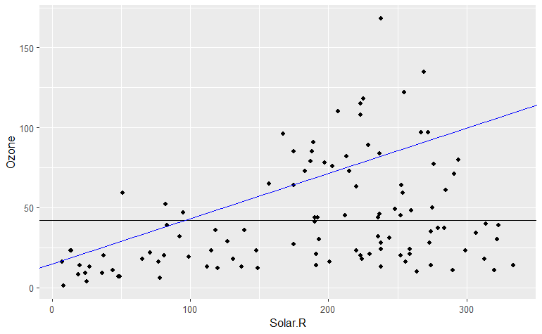

```r
ggplot(airquality %>% na.omit) +
  geom_point(aes(Solar.R, Ozone)) +
  geom_hline(aes(yintercept=mean.Ozone)) +
  geom_abline(aes(intercept=15, slope=85/300), color="blue")
```

## Linear Regression

We do a linear regression to model the dependency of `Ozone` on `Solar.R`.

```r
?lm
#use lm to fit regression line thru these data
model1=lm(Ozone~Solar.R, data=airquality)
#notice it ignores the NA values automatically
model1
```

```
Call:
lm(formula = Ozone ~ Solar.R, data = airquality)

Coefficients:
(Intercept)      Solar.R
    18.5987       0.1272
```

It tells us the best fitting coefficients are, intercept of about 18.6 and slope of about .127.

Let’s put it on the same plot. We grab the coefficients from the model using the `coef()` function.

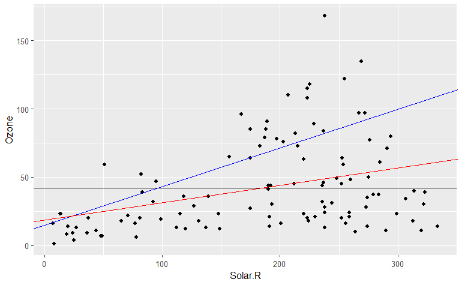

```r
ggplot(airquality) +
  geom_point(aes(Solar.R,Ozone)) +
  geom_hline(aes(yintercept=mean.Ozone)) +
  geom_abline(aes(intercept=15, slope=85/300), color="blue") +
  geom_abline(aes(intercept=coef(model1)[1],
                  slope=coef(model1)[2]),
              color="red")
```

Our blue guess was quite wrong. The red line is the real regression line.

## Residuals

Residual analysis should be next!!! No regression is better than its residuals.

```r
residuals(model1) %>% head
```

```
         1          2          3          4          7          8
 -1.760129   2.395770 -25.546353 -40.401458 -33.621144 -12.188090
```

Plot the residuals in a nice MBAD640 way.

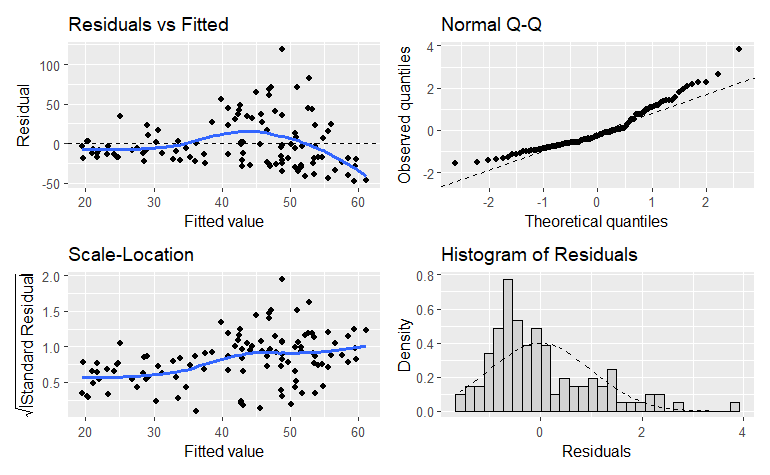

```r
model1 %>% gg_residual_plots()
```

## Partial Residual Plots

The modern way:

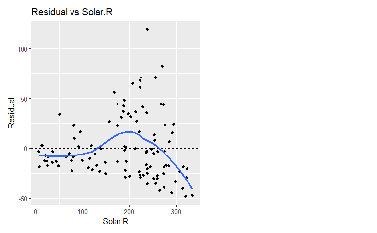

```r
model1 %>% gg_partial_residual_plots()
```

## Basic Regression Output

The basic report from a regression. Can be useful for a quick look, but you can’t retrieve any of the values from the `summary` object.

```r
summary(model1)
```

```
Call:
lm(formula = Ozone ~ Solar.R, data = airquality)

Residuals:
    Min      1Q  Median      3Q     Max
-48.292 -21.361  -8.864  16.373 119.136

Coefficients:
            Estimate Std. Error t value Pr(>|t|)
(Intercept) 18.59873    6.74790   2.756 0.006856 **
Solar.R      0.12717    0.03278   3.880 0.000179 ***
---
Signif. codes:  0 ‘***’ 0.001 ‘**’ 0.01 ‘*’ 0.05 ‘.’ 0.1 ‘ ’ 1

Residual standard error: 31.33 on 109 degrees of freedom
  (42 observations deleted due to missingness)
Multiple R-squared:  0.1213,    Adjusted R-squared:  0.1133
F-statistic: 15.05 on 1 and 109 DF,  p-value: 0.0001793
```

## `tidy` Regression Output

```r
model1 %>% tidy(conf.int=TRUE) # shows just the coefficient part
```

| term | estimate | std.error | statistic | p.value | conf.low | conf.high |
| --- | --- | --- | --- | --- | --- | --- |
| (Intercept) | 18.5987278 | 6.74790416 | 2.756223 | 0.0068560215 | 5.22460110 | 31.9728544 |
| Solar.R | 0.1271653 | 0.03277629 | 3.879795 | 0.0001793109 | 0.06220373 | 0.1921268 |

```r
model1 %>% glance() #shows just the overall part, the R-squared etc.
```

| r.squared | adj.r.squared | sigma | statistic | p.value | df | logLik | AIC | BIC | deviance | df.residual | nobs |
| --- | --- | --- | --- | --- | --- | --- | --- | --- | --- | --- | --- |
| 0.1213419 | 0.1132809 | 31.33457 | 15.05281 | 0.0001793109 | 1 | -538.8572 | 1083.714 | 1091.843 | 107022.2 | 109 | 111 |

```r
model1 %>% augment() # shows all observations, the fitted and residuals, and various numbers related to outlier analysis.
```

| .rownames | Ozone | Solar.R | .fitted | .resid | .hat | .sigma | .cooksd | .std.resid |
| --- | --- | --- | --- | --- | --- | --- | --- | --- |
| 1 | 41 | 190 | 42.76013 | -1.7601294 | 0.009038574 | 31.47884 | 1.452105e-05 | -0.056427716 |
| 2 | 36 | 118 | 33.60423 | 2.3957702 | 0.013891578 | 31.47845 | 4.175563e-05 | 0.076994388 |
| 3 | 12 | 149 | 37.54635 | -25.5463532 | 0.010411441 | 31.38216 | 3.533311e-03 | -0.819554483 |
| 4 | 18 | 313 | 58.40146 | -40.4014578 | 0.026990921 | 31.23161 | 2.369739e-02 | -1.307118134 |
| 7 | 23 | 299 | 56.62114 | -33.6211440 | 0.023277910 | 31.30864 | 1.404590e-02 | -1.085683485 |
| 8 | 19 | 99 | 31.18809 | -12.1880897 | 0.017063996 | 31.45707 | 1.336054e-03 | -0.392327968 |
| 9 | 8 | 19 | 21.01487 | -13.0148679 | 0.039087118 | 31.45337 | 3.651469e-03 | -0.423715165 |
| 12 | 16 | 256 | 51.15304 | -35.1530373 | 0.014555394 | 31.29434 | 9.432086e-03 | -1.130115930 |
| 13 | 11 | 290 | 55.47666 | -44.4766565 | 0.021117461 | 31.18068 | 2.220073e-02 | -1.434640516 |
| 14 | 14 | 274 | 53.44201 | -39.4420122 | 0.017714318 | 31.24552 | 1.454419e-02 | -1.270037096 |

[output cut: 101 more lines]

# Gottingen 2

[This video](https://youtu.be/ksOErR1ldgo) covers more than one variable plus interaction. We will work with `Ozone` as it depends on `Solar.R` and `Wind`.

## Univariate variation

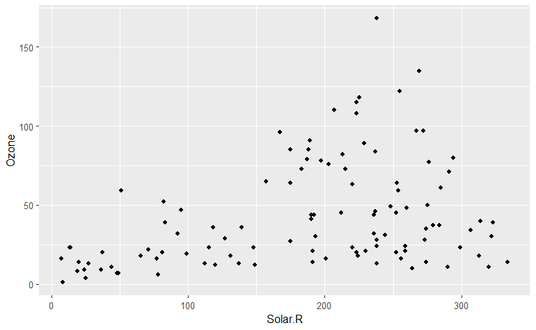

```r
airquality %>% ggplot() +
  geom_point(aes(Solar.R, Ozone))
```

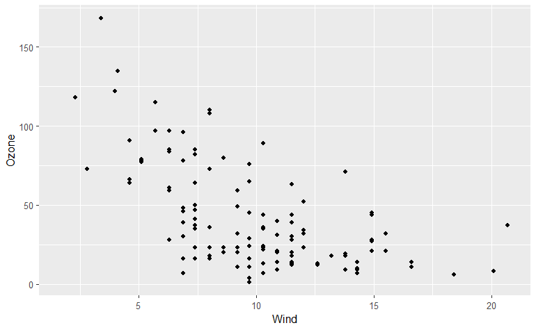

```r
airquality %>% ggplot() +
  geom_point(aes(Wind, Ozone))
```

`Solar.R` pushes `Ozone` up, and `Wind` pushes it down. We can do a pairs plot.

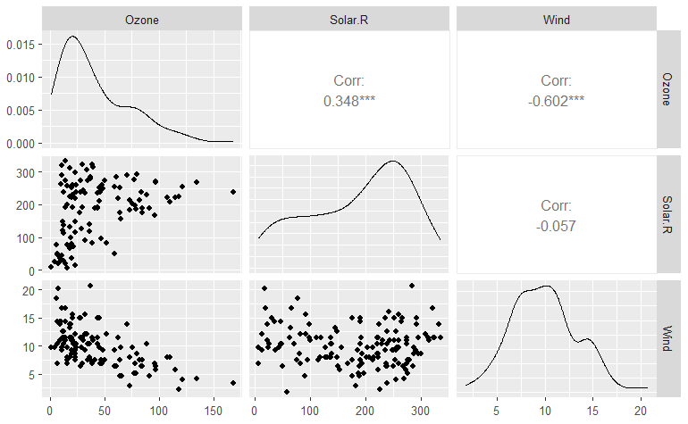

```r
ggpairs(airquality, columns=1:3, progress=FALSE)
```

## Interactions

Look for an interaction between variables.

```
 Missing rows: 5, 6, 10, 11, 25, 26, 27, 32, 33, 34, 35, 36, 37, 39, 42, 43, 45, 46, 52, 53, 54, 55, 56, 57, 58, 59, 60, 61, 65, 72, 75, 83, 84, 96, 97, 98, 102, 103, 107, 115, 119, 150
```

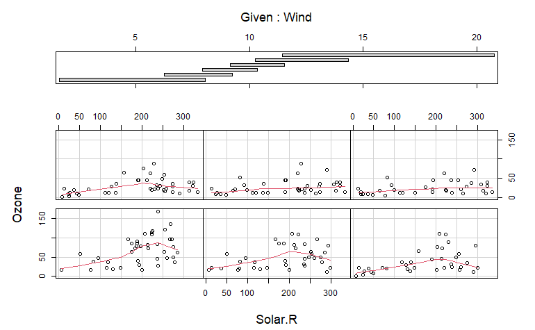

```r
coplot(Ozone~Solar.R|Wind, panel=panel.smooth, data=airquality)
```

The ggplot way is to use the `ggcleveland` package. We did not attempt to replicate the default plot above by setting the cutpoints or bins for `Wind`.

This package would be a good candidate for my MBAD standard packages. There are several nice plots. But the documentation is in Spanish!!!

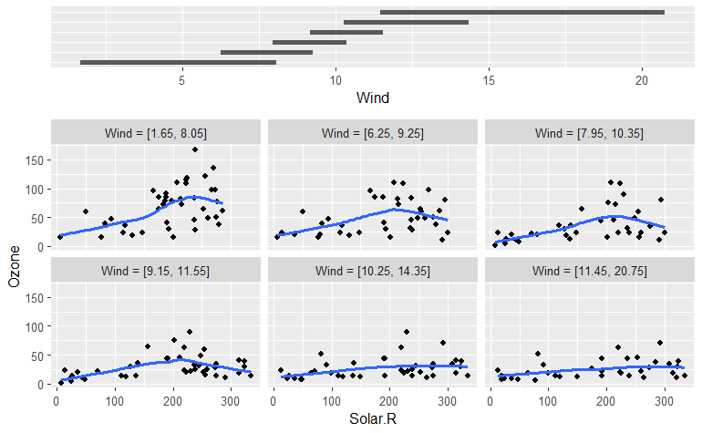

```r
library(ggcleveland)
airquality %>% gg_coplot(x=Solar.R, y=Ozone, faceting=Wind)
```

## Regression

We will do a regression with Ozone dependent on Solar.R, Wind, and interactions.

```r
model2=lm(Ozone~Solar.R*Wind, data=airquality)
```

Next a residual plot.

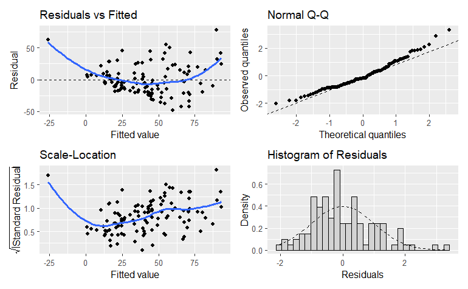

```r
model2 %>% gg_residual_plots()
```

This plot raises eyebrows. The big parabola curve in the Residual Plot indicates nonlinear relations with the predicted values. A square root transform might be indicated.

Finally a summary. And the modern versions.

```r
summary(model2)
```

```
Call:
lm(formula = Ozone ~ Solar.R * Wind, data = airquality)

Residuals:
    Min      1Q  Median      3Q     Max
-48.694 -17.200  -4.384  12.740  78.218

Coefficients:
              Estimate Std. Error t value Pr(>|t|)
(Intercept)  34.467686  17.634602   1.955 0.053246 .
Solar.R       0.324141   0.083928   3.862 0.000193 ***
Wind         -1.594546   1.508979  -1.057 0.293026
Solar.R:Wind -0.020279   0.007246  -2.799 0.006089 **
---
Signif. codes:  0 ‘***’ 0.001 ‘**’ 0.01 ‘*’ 0.05 ‘.’ 0.1 ‘ ’ 1

Residual standard error: 24.16 on 107 degrees of freedom
  (42 observations deleted due to missingness)
Multiple R-squared:  0.487, Adjusted R-squared:  0.4727
F-statistic: 33.86 on 3 and 107 DF,  p-value: 1.807e-15
```

```r
model2 %>% glance()
```

| r.squared | adj.r.squared | sigma | statistic | p.value | df | logLik | AIC | BIC | deviance | df.residual | nobs |
| --- | --- | --- | --- | --- | --- | --- | --- | --- | --- | --- | --- |
| 0.4870409 | 0.4726589 | 24.16443 | 33.86454 | 1.807189e-15 | 3 | -508.9871 | 1027.974 | 1041.522 | 62479.4 | 107 | 111 |

```r
model2 %>% augment()
```

| .rownames | Ozone | Solar.R | Wind | .fitted | .resid | .hat | .sigma | .cooksd | .std.resid |
| --- | --- | --- | --- | --- | --- | --- | --- | --- | --- |
| 1 | 41 | 190 | 7.4 | 55.7423021 | -14.7423021 | 0.013729927 | 24.23529 | 1.313391e-03 | -0.61431462 |
| 2 | 36 | 118 | 8.0 | 40.8164063 | -4.8164063 | 0.023248540 | 24.27353 | 2.420253e-04 | -0.20167616 |
| 3 | 12 | 149 | 12.6 | 24.6012736 | -12.6012736 | 0.014958462 | 24.24680 | 1.048078e-03 | -0.52542490 |
| 4 | 18 | 313 | 11.5 | 44.5916116 | -26.5916116 | 0.031339780 | 24.13590 | 1.011182e-02 | -1.11810452 |
| 7 | 23 | 299 | 8.6 | 65.5268526 | -42.5268526 | 0.028608851 | 23.91368 | 2.347608e-02 | -1.78562249 |
| 8 | 19 | 99 | 13.8 | 16.8474886 | 2.1525114 | 0.029553470 | 24.27722 | 6.225054e-05 | 0.09042388 |
| 9 | 8 | 19 | 20.1 | 0.8313729 | 7.1686271 | 0.302886070 | 24.26382 | 1.371294e-02 | 0.35531012 |
| 12 | 16 | 256 | 9.7 | 51.6234130 | -35.6234130 | 0.014822279 | 24.02657 | 8.297435e-03 | -1.48525736 |
| 13 | 11 | 290 | 9.2 | 59.6938865 | -48.6938865 | 0.023176324 | 23.80186 | 2.465744e-02 | -2.03887137 |
| 14 | 14 | 274 | 10.9 | 45.3359535 | -31.3359535 | 0.019212259 | 24.08284 | 8.396556e-03 | -1.30941972 |

[output cut: 101 more lines]

```r
model2 %>% tidy(conf.int=TRUE) %>% gt_add_significance()
```

| term | estimate | std.error | statistic | p.value | conf.low | conf.high |
| --- | --- | --- | --- | --- | --- | --- |
| (Intercept) | 34.4677 | 17.6346 | 1.9545 | 0.0532 | −0.4909 | 69.4262 |
| Solar.R | 0.3241 | 0.0839 | 3.8622 | 0.0002 | 0.1578 | 0.4905 |
| Wind | −1.5945 | 1.5090 | −1.0567 | 0.2930 | −4.5859 | 1.3968 |
| Solar.R:Wind | −0.0203 | 0.0072 | −2.7986 | 0.0061 | −0.0346 | −0.0059 |

The solar and wind coefficients are conditioned on 0 for the other. We can see there is a sizeable and meaningful (nonzero coefficient) interaction term, as well as a significant Solar.R term.

The partial plots ignore the interaction.

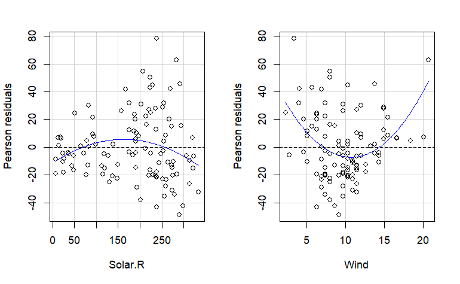

```r
model2 %>% car::residualPlots(fitted=FALSE, tests=FALSE)
```

A summary of `Solar.R`:

```r
summary(airquality$Solar.R)
```

```
   Min. 1st Qu.  Median    Mean 3rd Qu.    Max.     NAs
    7.0   115.8   205.0   185.9   258.8   334.0       7
```

## Predictions

The `predict` function uses the model to make predictions. If we don’t tell it the `newdata` parameter, it uses all the values of the drivers to make predictions at. We could also use augment, which would give us a lot more in a nice format. The `augment` output predictions are in the `.fitted` column.

```r
model2 %>% predict()
```

```
          1           2           3           4           7           8
 55.7423021  40.8164063  24.6012736  44.5916116  65.5268526  16.8474886
          9          12          13          14          15          16
  0.8313729  51.6234130  59.6938865  45.3359535  17.0893046  46.5011492
         17          18          19          20          21          22
 40.1359014   1.3063527  45.4099849  24.6076392  20.0200550   4.0003072
         23          24          28          29          30          31
 22.1864142  22.7658868  16.3834164  16.2481965  71.8853456  71.2349793
         38          40          41          44          47          48
 35.1845695  25.3508285  45.5009152  45.6736317  14.9073480 -25.7006502
         49          50          51          62          63          64
 24.8880468  27.0420524  33.8352218  92.7580646  53.9158420  52.2649721
         66          67          68          69          70          71
 67.5327066  49.4598683  87.2534376  76.8560767  82.1042781  53.1311767
         73          74          76          77          78          79
 20.6809207  14.5556501  13.3048155  71.3611211  49.6265793  80.3909550
         80          81          82          85          86          87
 67.6096107  36.1350883  24.7548224  64.7781526  57.8166952  32.8835323
         88          89          90          91          92          93
 21.9579792  59.7460276  70.5386792  66.7090287  54.7412769  38.7551335
         94          95          99         100         101         104
 13.5258714  36.0718242  90.0606897  44.4396371  55.2261750  33.5890382
        105         106         108         109         110         111
 40.9543973  39.0075564  26.2277065  34.4375363  42.6866751  42.2430174
        112         113         114         116         117         118
 39.9442871  12.2939512  12.8950319  46.0163656  89.7818726  56.5214351
        120         121         122         123         124         125
 44.8694696  93.2374788  70.9646127  61.3418883  54.2291615  69.8167823
        126         127         128         129         130         131
 78.9297073  70.7647011  39.2051746  10.6550782  43.0678003  43.4022486
        132         133         134         135         136         137
 40.7996472  52.0057117  15.8964985  12.2939512  71.1609949  19.5614857
        138         139         140         141         142         143
 26.3146095  67.1241848  22.3835172  21.1560297  45.4770255  54.2547299
        144         145         146         147         148         149
 30.7087432  21.7238796  34.0657526  23.6918681   7.7483558  59.0187416
        151         152         153
 18.1880703  42.9212040  36.4078793
```

```r
model2 %>% augment()
```

| .rownames | Ozone | Solar.R | Wind | .fitted | .resid | .hat | .sigma | .cooksd | .std.resid |
| --- | --- | --- | --- | --- | --- | --- | --- | --- | --- |
| 1 | 41 | 190 | 7.4 | 55.7423021 | -14.7423021 | 0.013729927 | 24.23529 | 1.313391e-03 | -0.61431462 |
| 2 | 36 | 118 | 8.0 | 40.8164063 | -4.8164063 | 0.023248540 | 24.27353 | 2.420253e-04 | -0.20167616 |
| 3 | 12 | 149 | 12.6 | 24.6012736 | -12.6012736 | 0.014958462 | 24.24680 | 1.048078e-03 | -0.52542490 |
| 4 | 18 | 313 | 11.5 | 44.5916116 | -26.5916116 | 0.031339780 | 24.13590 | 1.011182e-02 | -1.11810452 |
| 7 | 23 | 299 | 8.6 | 65.5268526 | -42.5268526 | 0.028608851 | 23.91368 | 2.347608e-02 | -1.78562249 |
| 8 | 19 | 99 | 13.8 | 16.8474886 | 2.1525114 | 0.029553470 | 24.27722 | 6.225054e-05 | 0.09042388 |
| 9 | 8 | 19 | 20.1 | 0.8313729 | 7.1686271 | 0.302886070 | 24.26382 | 1.371294e-02 | 0.35531012 |
| 12 | 16 | 256 | 9.7 | 51.6234130 | -35.6234130 | 0.014822279 | 24.02657 | 8.297435e-03 | -1.48525736 |
| 13 | 11 | 290 | 9.2 | 59.6938865 | -48.6938865 | 0.023176324 | 23.80186 | 2.465744e-02 | -2.03887137 |
| 14 | 14 | 274 | 10.9 | 45.3359535 | -31.3359535 | 0.019212259 | 24.08284 | 8.396556e-03 | -1.30941972 |

[output cut: 101 more lines]

If we feed in some `newdata`, such as values for `Solar.R` and `Wind`, we get the prediction for those driver values. The `newdata` must be in a data frame. The result is the fitted value of Ozone at those two driver data values. It includes the interaction effect. `augment` can also be used to get data frame output.

```r
predict(model2, newdata = data.frame(Solar.R=100, Wind=10))
```

```
       1
30.65714
```

```r
model2 %>% augment(newdata = data.frame(Solar.R=100, Wind=10))
```

| Solar.R | Wind | .fitted |
| --- | --- | --- |
| 100 | 10 | 30.65714 |

Let’s do some more, fixing `Solar.R` and the three values computed above, and letting Wind vary from 1 to 20.

```r
p1=predict(model2,
           newdata = data.frame(
             Solar.R = mean(airquality$Solar.R, na.rm = TRUE),
             Wind= 1:20))
p2=predict(model2, data.frame(Solar.R=100, Wind=1:20))
p3=predict(model2, data.frame(Solar.R=300, Wind=1:20))
```

Do it all at once:

```r
M = mean(airquality$Solar.R, na.rm = TRUE)
newpoints = data.frame(
  Group = c(rep(1, 20, 2, 20, 3, 20)),
  Solar.R = c(
    rep(M, 20),
    rep(100, 20),
    rep(300, 20)
    ),
  Wind = rep(1:20,3)
  )
newpoints
```

| Group | Solar.R | Wind |
| --- | --- | --- |
| 1 | 185.9315 | 1 |
| 1 | 185.9315 | 2 |
| 1 | 185.9315 | 3 |
| 1 | 185.9315 | 4 |
| 1 | 185.9315 | 5 |
| 1 | 185.9315 | 6 |
| 1 | 185.9315 | 7 |
| 1 | 185.9315 | 8 |
| 1 | 185.9315 | 9 |
| 1 | 185.9315 | 10 |

[output cut: 50 more lines]

```r
model2 %>% augment(newdata=newpoints)
```

| Group | Solar.R | Wind | .fitted |
| --- | --- | --- | --- |
| 1 | 185.9315 | 1 | 89.370627 |
| 1 | 185.9315 | 2 | 84.005541 |
| 1 | 185.9315 | 3 | 78.640456 |
| 1 | 185.9315 | 4 | 73.275370 |
| 1 | 185.9315 | 5 | 67.910285 |
| 1 | 185.9315 | 6 | 62.545199 |
| 1 | 185.9315 | 7 | 57.180113 |
| 1 | 185.9315 | 8 | 51.815028 |
| 1 | 185.9315 | 9 | 46.449942 |
| 1 | 185.9315 | 10 | 41.084856 |

[output cut: 50 more lines]

What are the units of measure?

```r
?airquality
```

Let’s plot the results.

```r
D = model2 %>% augment(newdata=newpoints)
D
```

| Group | Solar.R | Wind | .fitted |
| --- | --- | --- | --- |
| 1 | 185.9315 | 1 | 89.370627 |
| 1 | 185.9315 | 2 | 84.005541 |
| 1 | 185.9315 | 3 | 78.640456 |
| 1 | 185.9315 | 4 | 73.275370 |
| 1 | 185.9315 | 5 | 67.910285 |
| 1 | 185.9315 | 6 | 62.545199 |
| 1 | 185.9315 | 7 | 57.180113 |
| 1 | 185.9315 | 8 | 51.815028 |
| 1 | 185.9315 | 9 | 46.449942 |
| 1 | 185.9315 | 10 | 41.084856 |

[output cut: 50 more lines]

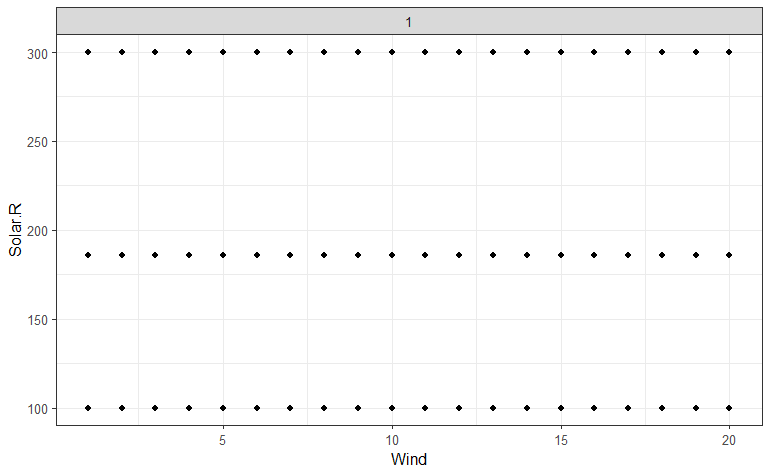

```r
ggplot(D)+
  geom_point(aes(Wind, Solar.R)) +
  facet_wrap(newpoints$Group) +
  # geom_line(aes(1:20, p1)) +
  # geom_line(aes(1:20, p2), color="green")+
  # geom_line(aes(1:20, p3), color="red")+
  theme_bw()
```

# Gottingen 3

[This video](https://youtu.be/P-WYkSZp9lY) covers problems in regression and censoring.

## Introduction

We study fitting models different from `lm()`. Why?

- Use `glm` when there is not normal error and not constant variance
- Use `gls` for correlated errors or space/temporal patterns or trends

```r
airquality
```

| Ozone | Solar.R | Wind | Temp | Month | Day |
| --- | --- | --- | --- | --- | --- |
| 41 | 190 | 7.4 | 67 | 5 | 1 |
| 36 | 118 | 8.0 | 72 | 5 | 2 |
| 12 | 149 | 12.6 | 74 | 5 | 3 |
| 18 | 313 | 11.5 | 62 | 5 | 4 |
| NA | NA | 14.3 | 56 | 5 | 5 |
| 28 | NA | 14.9 | 66 | 5 | 6 |
| 23 | 299 | 8.6 | 65 | 5 | 7 |
| 19 | 99 | 13.8 | 59 | 5 | 8 |
| 8 | 19 | 20.1 | 61 | 5 | 9 |
| NA | 194 | 8.6 | 69 | 5 | 10 |

[output cut: 143 more lines]

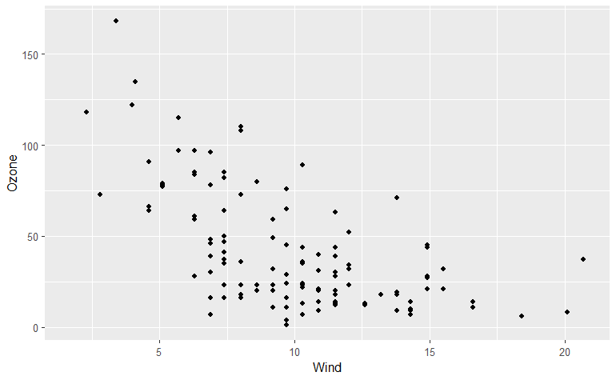

```r
ggplot(airquality) +
  geom_point(aes(Wind, Ozone))
```

## Regression

A linear predictor.
$$y = a + bx +
u$$

```r
model1 = lm(Ozone~Wind, data=airquality)
```

## Residual analysis

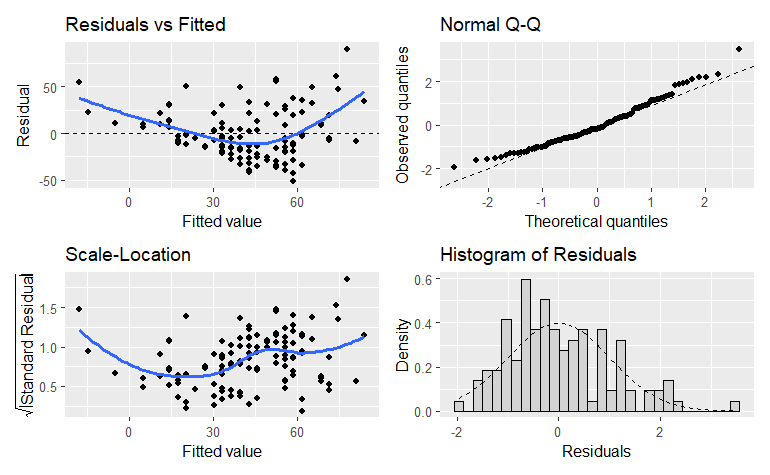

There are problems with the residuals.

Coefficients:

```r
coef(model1)
```

```
(Intercept)        Wind
  96.872895   -5.550923
```

Predictions of windspeeds of 19 and 20.

```r
ozone19=coef(model1)[1]+ coef(model1)[2]*19
ozone20=coef(model1)[1]+ coef(model1)[2]*20
ozone19; ozone20
```

```
(Intercept)
   -8.59464
(Intercept)
  -14.14556
```

```r
predict(model1, newdata=data.frame(Wind=19:20))
```

```
        1         2
 -8.59464 -14.14556
```

```r
augment(model1, newdata=data.frame(Wind=19:20))
```

| Wind | .fitted |
| --- | --- |
| 19 | -8.59464 |
| 20 | -14.14556 |

Proves that the linear equation is how the `predict` function does it.

## Issues

Negative values of ozone are impossible. But we got them for nominal wind speeds.

## `glm` Model

```r
model2=glm(Ozone~Wind, data=airquality, family=poisson)
```

```r
coef(model2)
```

```
(Intercept)        Wind
  5.0795877  -0.1488753
```

Make predictions with the new model.

```r
ozone19.glm=exp(coef(model2)[1]+ coef(model2)[2]*19)
ozone20.glm=exp(coef(model2)[1]+ coef(model2)[2]*20)
ozone19.glm; ozone20.glm
```

```
(Intercept)
   9.496811
(Intercept)
   8.183179
```

```r
exp(predict(model2, newdata=data.frame(Wind=19:20)))
```

```
       1        2
9.496811 8.183179
```

These are the same:

```r
ozone20.glm/ozone19.glm
```

```
(Intercept)
  0.8616765
```

```r
exp(coef(model2)[2])
```

```
     Wind
0.8616765
```

The slope of the glm model gives us the proportional change if we change wind speed by 1 unit.

## `gls` Models

This function is in the package `nlme`, so install it first. Here we have to exclude the missing values.

```r
library(nlme)
?gls
model3=gls(Ozone~Wind, data=airquality, na.action=na.exclude) #missing values
summary(model3)
```

```
Generalized least squares fit by REML
  Model: Ozone ~ Wind
  Data: airquality
```

|  | AIC | BIC | logLik |
| --- | --- | --- | --- |
|  | 1088.472 | 1096.68 | -541.2359 |

```
Coefficients:
```

|  | Value | Std.Error | t-value | p-value |
| --- | --- | --- | --- | --- |
| (Intercept) | 96.87289 | 7.238689 | 13.38266 | 0 |
| Wind | -5.55092 | 0.690402 | -8.04013 | 0 |

```
 Correlation:
     (Intr)
Wind -0.941

Standardized residuals:
       Min         Q1        Med         Q3        Max
-1.9485001 -0.7123616 -0.1839189  0.5755787  3.4004323

Residual standard error: 26.46729
Degrees of freedom: 116 total; 114 residual
```

This is not a linear model, so we need to measure the quality of the regression by AIC or BIC rather than R-squared.

## Comparing `gls` regressions

We will convert the date information in `airquality` into a date field we can use. There are month and day data.

```r
head(airquality)
```

[output not shown]

```r
# get a date - all the data are from 1973
paste(1973, airquality$Month,airquality$Day, sep="-")
```

```
  [1] "1973-5-1"  "1973-5-2"  "1973-5-3"  "1973-5-4"  "1973-5-5"  "1973-5-6"
  [7] "1973-5-7"  "1973-5-8"  "1973-5-9"  "1973-5-10" "1973-5-11" "1973-5-12"
 [13] "1973-5-13" "1973-5-14" "1973-5-15" "1973-5-16" "1973-5-17" "1973-5-18"
 [19] "1973-5-19" "1973-5-20" "1973-5-21" "1973-5-22" "1973-5-23" "1973-5-24"
 [25] "1973-5-25" "1973-5-26" "1973-5-27" "1973-5-28" "1973-5-29" "1973-5-30"
 [31] "1973-5-31" "1973-6-1"  "1973-6-2"  "1973-6-3"  "1973-6-4"  "1973-6-5"
 [37] "1973-6-6"  "1973-6-7"  "1973-6-8"  "1973-6-9"  "1973-6-10" "1973-6-11"
 [43] "1973-6-12" "1973-6-13" "1973-6-14" "1973-6-15" "1973-6-16" "1973-6-17"
 [49] "1973-6-18" "1973-6-19" "1973-6-20" "1973-6-21" "1973-6-22" "1973-6-23"
 [55] "1973-6-24" "1973-6-25" "1973-6-26" "1973-6-27" "1973-6-28" "1973-6-29"
 [61] "1973-6-30" "1973-7-1"  "1973-7-2"  "1973-7-3"  "1973-7-4"  "1973-7-5"
 [67] "1973-7-6"  "1973-7-7"  "1973-7-8"  "1973-7-9"  "1973-7-10" "1973-7-11"
 [73] "1973-7-12" "1973-7-13" "1973-7-14" "1973-7-15" "1973-7-16" "1973-7-17"
 [79] "1973-7-18" "1973-7-19" "1973-7-20" "1973-7-21" "1973-7-22" "1973-7-23"
 [85] "1973-7-24" "1973-7-25" "1973-7-26" "1973-7-27" "1973-7-28" "1973-7-29"
 [91] "1973-7-30" "1973-7-31" "1973-8-1"  "1973-8-2"  "1973-8-3"  "1973-8-4"
 [97] "1973-8-5"  "1973-8-6"  "1973-8-7"  "1973-8-8"  "1973-8-9"  "1973-8-10"
[103] "1973-8-11" "1973-8-12" "1973-8-13" "1973-8-14" "1973-8-15" "1973-8-16"
[109] "1973-8-17" "1973-8-18" "1973-8-19" "1973-8-20" "1973-8-21" "1973-8-22"
[115] "1973-8-23" "1973-8-24" "1973-8-25" "1973-8-26" "1973-8-27" "1973-8-28"
[121] "1973-8-29" "1973-8-30" "1973-8-31" "1973-9-1"  "1973-9-2"  "1973-9-3"
[127] "1973-9-4"  "1973-9-5"  "1973-9-6"  "1973-9-7"  "1973-9-8"  "1973-9-9"
[133] "1973-9-10" "1973-9-11" "1973-9-12" "1973-9-13" "1973-9-14" "1973-9-15"
[139] "1973-9-16" "1973-9-17" "1973-9-18" "1973-9-19" "1973-9-20" "1973-9-21"
[145] "1973-9-22" "1973-9-23" "1973-9-24" "1973-9-25" "1973-9-26" "1973-9-27"
[151] "1973-9-28" "1973-9-29" "1973-9-30"
```

```r
airquality$Date=as.Date(paste(1973,airquality$Month,airquality$Day,sep="-"))
```

Now make some plots.

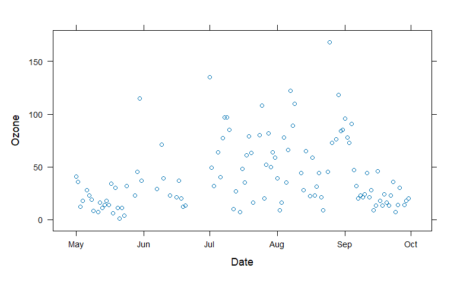

```r
library(lattice)
xyplot(Ozone~Date,airquality)
```

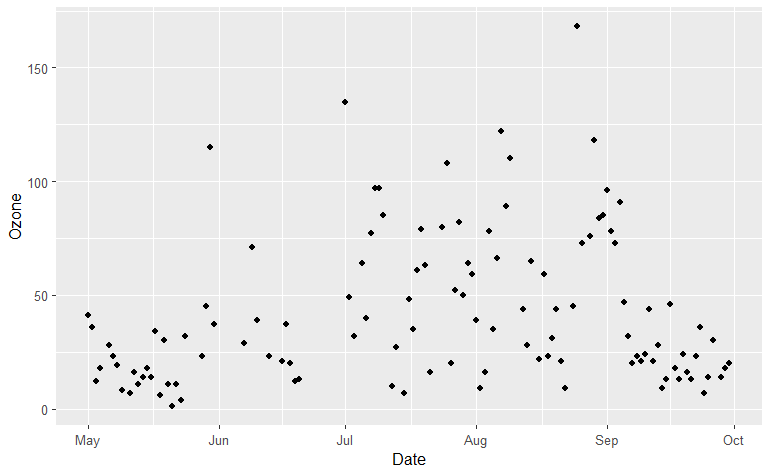

```r
ggplot(airquality) +
  geom_point(aes(Date, Ozone))
```

## Models with correlation and interaction

We will make sure we have only complete cases with Ozone numbers. Then we make a model with interactions, and then update it with an AR1 correlation matrix. Model 6 is required because of the ACF plot of model 5.

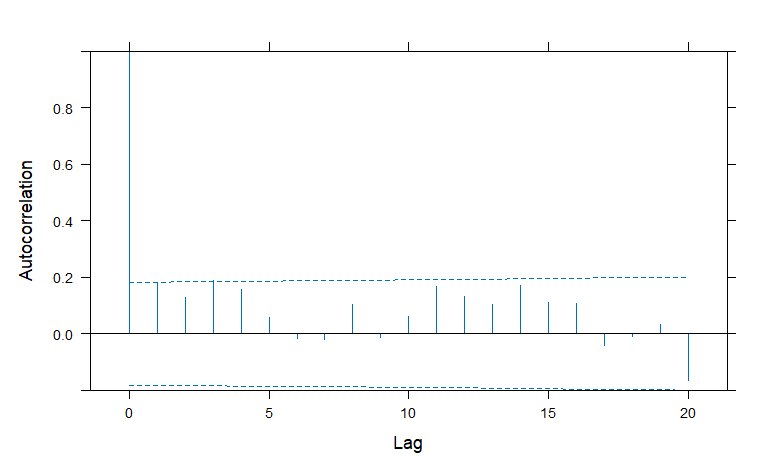

```r
air2=subset(airquality, complete.cases(Ozone))
model5=gls(Ozone~Wind*Date, air2)
plot(ACF(model5,form=~Date), alpha=0.05)
```

```r
model6=Matrix::update(model5,correlation=corAR1())
```

Now we compare `model5` with `model6`.

```r
(model5 %>% summary)$AIC
```

```
[1] 1098.854
```

```r
(model6 %>% summary)$AIC
```

```
[1] 1094.439
```

The `gls` model `model6` is slightly better than `model5`. Smaller AIC is better.

# Gottingen 4

Now we try to understand contrasts!! [The Video](https://youtu.be/eVSIDf5w1_I).

We use a new dataset, `OrchardSprays`. It is a latin square design of an experiment with lime sulfur in the cells of a honeycomb.

There are 8 rows and 8 columns, H is the control treatment. y ~ treatment (8 levels) The summary table has intercept (first in alphabet) and a line for each treatment.

```r
data(OrchardSprays)
?OrchardSprays
str(OrchardSprays)
```

```
'data.frame':   64 obs. of  4 variables:
 $ decrease : num  57 95 8 69 92 90 15 2 84 6 ...
 $ rowpos   : num  1 2 3 4 5 6 7 8 1 2 ...
 $ colpos   : num  1 1 1 1 1 1 1 1 2 2 ...
 $ treatment: Factor w/ 8 levels "A","B","C","D",..: 4 5 2 8 7 6 3 1 3 2 ...
```

Always plot the data.

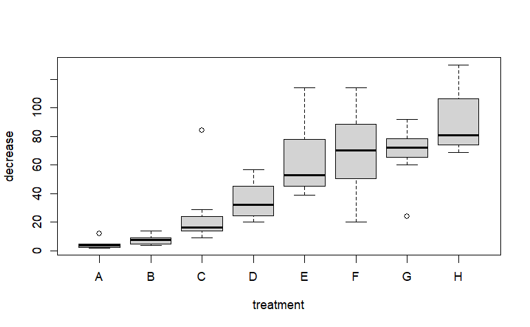

```r
plot(decrease~treatment, data=OrchardSprays)
```

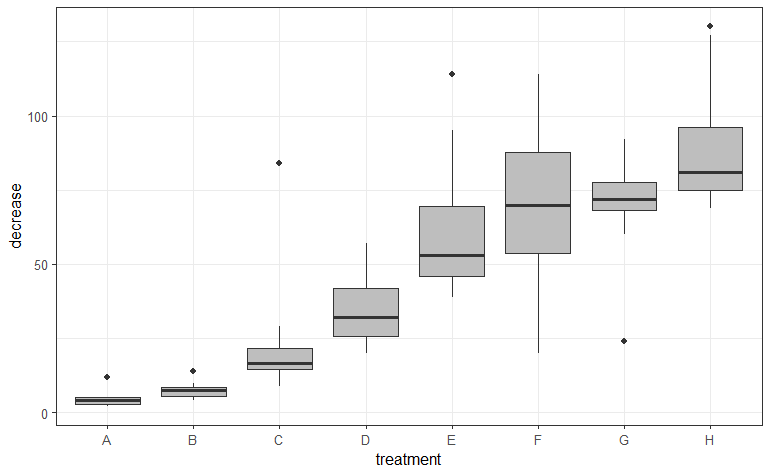

```r
ggplot(OrchardSprays) +
  geom_boxplot(aes(treatment, decrease), fill="gray")+
  theme_bw()
```

## Linear Model

```r
model1=lm(decrease~treatment,data=OrchardSprays)
summary(model1)
```

```
Call:
lm(formula = decrease ~ treatment, data = OrchardSprays)

Residuals:
    Min      1Q  Median      3Q     Max
-49.000  -9.500  -1.625   3.812  58.750

Coefficients:
            Estimate Std. Error t value Pr(>|t|)
(Intercept)    4.625      7.253   0.638  0.52631
treatmentB     3.000     10.258   0.292  0.77101
treatmentC    20.625     10.258   2.011  0.04918 *
treatmentD    30.375     10.258   2.961  0.00449 **
treatmentE    58.500     10.258   5.703 4.60e-07 ***
treatmentF    64.375     10.258   6.276 5.39e-08 ***
treatmentG    63.875     10.258   6.227 6.48e-08 ***
treatmentH    85.625     10.258   8.347 2.08e-11 ***
---
Signif. codes:  0 ‘***’ 0.001 ‘**’ 0.01 ‘*’ 0.05 ‘.’ 0.1 ‘ ’ 1

Residual standard error: 20.52 on 56 degrees of freedom
Multiple R-squared:  0.7044,    Adjusted R-squared:  0.6674
F-statistic: 19.06 on 7 and 56 DF,  p-value: 9.499e-13
```

## `gls` model

We also make a `gls` model and then update it with weights set specially. Why? Because the variances of the different treatments vary. In the plot we see that the variances are not the same throughout. So we would expect not to be able to use anova. The gls does that. The `varIdent` makes variance depends on treatment.

```r
model2=gls(decrease~treatment, data=OrchardSprays)
model3=Matrix::update(model2, weights=varIdent(form=~1|treatment))
AIC(model2,model3)
```

|  | df | AIC |
| --- | --- | --- |
| model2 | 9 | 531.9289 |
| model3 | 16 | 501.6458 |

```r
summary(model3)
```

[output not shown]

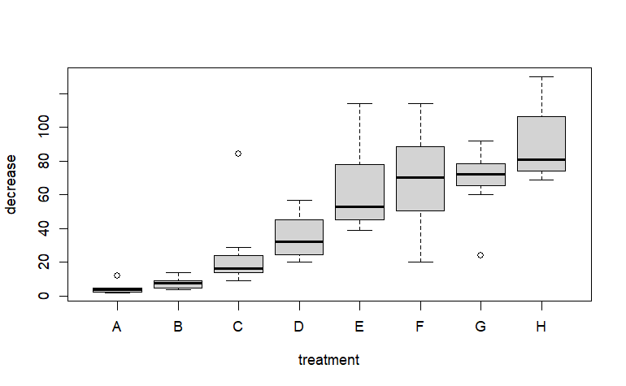

```r
plot(decrease~treatment, data=OrchardSprays)
```

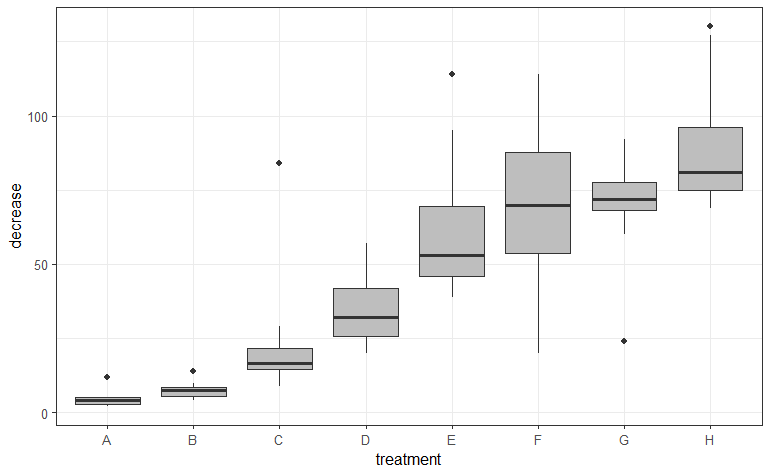

```r
OrchardSprays %>% ggplot() +
  geom_boxplot(aes(treatment, decrease), fill="gray") +
  theme_bw()
```

## Successive Difference Contrasts

You may need to install the `MASS` package.

```r
library(MASS)
?contr.sdif()
# contrasts by successive differences
options(contrasts = c("contr.sdif","contr.sdif"))
```

Now we run our two models again, after setting the options for successive difference contrasts.

```r
model4=gls(decrease~treatment,data=OrchardSprays)
model5=Matrix::update(model4,weights=varIdent(form=~1|treatment))
```

```r
summary(model5)
```

```
Generalized least squares fit by REML
  Model: decrease ~ treatment
  Data: OrchardSprays
```

|  | AIC | BIC | logLik |
| --- | --- | --- | --- |
|  | 501.6458 | 534.0515 | -234.8229 |

```
Variance function:
 Structure: Different standard deviations per stratum
 Formula: ~1 | treatment
 Parameter estimates:
        D         E         B         H         G         F         C         A
1.0000000 2.0025451 0.2450055 1.8026660 1.4989448 2.1721775 1.8179616 0.2384599

Coefficients:
```

|  | Value | Std.Error | t-value | p-value |
| --- | --- | --- | --- | --- |
| (Intercept) | 45.42187 | 2.564439 | 17.712209 | 0.0000 |
| treatmentB-A | 3.00000 | 1.624313 | 1.846935 | 0.0700 |
| treatmentC-B | 17.62500 | 8.715109 | 2.022350 | 0.0479 |
| treatmentD-C | 9.75000 | 9.857466 | 0.989098 | 0.3269 |
| treatmentE-D | 28.12500 | 10.634240 | 2.644759 | 0.0106 |
| treatmentF-E | 5.87500 | 14.036226 | 0.418560 | 0.6771 |
| treatmentG-F | -0.50000 | 12.538512 | -0.039877 | 0.9683 |
| treatmentH-G | 21.75000 | 11.138334 | 1.952716 | 0.0559 |

```
 Correlation:
             (Intr) trtB-A trtC-B trtD-C trtE-D trtF-E trtG-F
treatmentB-A  0.002
treatmentC-B  0.410 -0.096
treatmentD-C -0.257  0.000 -0.868
treatmentE-D  0.311  0.000  0.000 -0.215
treatmentF-E  0.056  0.000  0.000  0.000 -0.606
treatmentG-F -0.217  0.000  0.000  0.000  0.000 -0.605
treatmentH-G  0.099  0.000  0.000  0.000  0.000  0.000 -0.363

Standardized residuals:
       Min         Q1        Med         Q3        Max
-2.2092755 -0.5900360 -0.1950474  0.3287518  2.4049091

Residual standard error: 13.43769
Degrees of freedom: 64 total; 56 residual
```

# Conclusion

We have completed the coding for the four Gottingen videos. Hope you enjoy watching and learning.